# decision_tree

## Decision Trees

### Agenda

1. Introduction to Decision Trees
2. The Decision Tree Algorithms
3. Decision Tree for Classification

### 1. Introduction to Decision Trees

```
* Non-parametric supervised learning method for regression & classification
* It's similar to playing 'dumb charades'.
* A good algorithm will have less & right questions compared to not-so-good one
* The nodes are questions & leafs are prediction
```

```python
import pandas as pd
import numpy as np
import matplotlib.pyplot as plt
import math
%matplotlib inline
```

### import data

```python
play_data = pd.read_csv('./DSVC/datasets/tennis.csv.txt')
```

### show data

```python
play_data
```

|  | outlook | temp | humidity | windy | play |
| --- | --- | --- | --- | --- | --- |
| 0 | sunny | hot | high | False | no |
| 1 | sunny | hot | high | True | no |
| 2 | overcast | hot | high | False | yes |
| 3 | rainy | mild | high | False | yes |
| 4 | rainy | cool | normal | False | yes |
| 5 | rainy | cool | normal | True | no |
| 6 | overcast | cool | normal | True | yes |
| 7 | sunny | mild | high | False | no |
| 8 | sunny | cool | normal | False | yes |
| 9 | rainy | mild | normal | False | yes |
| 10 | sunny | mild | normal | True | yes |
| 11 | overcast | mild | high | True | yes |
| 12 | overcast | hot | normal | False | yes |
| 13 | rainy | mild | high | True | no |

- A decision tree for above data

[figure not shown]

### 2. Decision Tree Algorithm

- Decision Tree is based on (CART) which is advancement of ID3, developed in 1986 by Ross Quinlan.
- ID3 works when feature data & target data both are categorical in nature
- C4.5 is an advancement of ID3, it coverts continues features into categorical features. Then, proceeds with ID3
- CART is based on C4.5, with slight advancement of 'target can be continues'.
- scikit-learn decision trees are based on CART

#### Criterion of creating Decision Tree

- Entropy - Objective of CART is to maximize information gain in each split
- Gini Impurity - If classes are mixed, gini impurity is maximul ##### Both the approaches, yields almost same results. We will discuss algorithm using Entropy

### Entropy of play

- Entropy(play) = – p(Yes) . log2p(Yes) – p(No) . log2p(No)

```python
play_data.play.value_counts()
```

```
yes    9
no     5
Name: play, dtype: int64
```

### Calculation Entropy

根据上边公式，你需要完成下面代码块中Entropy_Play计算的代码

```python
Entropy_Play = -9/14* math.log(9/14,2)-5/14*math.log(5/14,2)
```

```python
Entropy_Play
```

```
0.9402859586706309
```

你的Entropy_Play正确结果应该为：0.940285

### Information Gain

- The information gain is based on the decrease in entropy after a dataset is split on an attribute.
- Constructing a decision tree is all about finding attribute that returns the highest information gain (i.e., the most homogeneous branches).
- Gain(S, A) = Entropy(S) – ∑ [ p(S|A) . Entropy(S|A) ]
- We intend to choose the attribute, splitting by which information gain will be the most
- Next step is calculating information gain for all attributes

#### Information Gain on splitting by Outlook

- Gain(Play, Outlook) = Entropy(Play) – ∑ [ p(Play|Outlook) . Entropy(Play|Outlook) ]
- Gain(Play, Outlook) = Entropy(Play) – [ p(Play|Outlook=Sunny) . Entropy(Play|Outlook=Sunny) ] – [ p(Play|Outlook=Overcast) . Entropy(Play|Outlook=Overcast) ] – [ p(Play|Outlook=Rain) . Entropy(Play|Outlook=Rain) ]

```python
play_data[play_data.outlook == 'sunny']
```

|  | outlook | temp | humidity | windy | play |
| --- | --- | --- | --- | --- | --- |
| 0 | sunny | hot | high | False | no |
| 1 | sunny | hot | high | True | no |
| 7 | sunny | mild | high | False | no |
| 8 | sunny | cool | normal | False | yes |
| 10 | sunny | mild | normal | True | yes |

### Calculation Information Gain

你需要完成下面代码块中Entropy_Play_Outlook_Sunny计算的代码

```python
Syes=2
Sno=3

Entropy_Play_Outlook_Sunny = -2/5 * math.log(2/5,2)-3/5*math.log(3/5,2)
```

```python
Entropy_Play_Outlook_Sunny
```

```
0.9709505944546686
```

你的Entropy_Play_Outlook_Sunny正确结果应该为：0.970951

```python
play_data[play_data.outlook == 'overcast']
```

|  | outlook | temp | humidity | windy | play |
| --- | --- | --- | --- | --- | --- |
| 2 | overcast | hot | high | False | yes |
| 6 | overcast | cool | normal | True | yes |
| 11 | overcast | mild | high | True | yes |
| 12 | overcast | hot | normal | False | yes |

```python
#Entropy_PlayOutlook_overcast=-4/4*math.log(4/4,2)-0/4*math.log(0/4,2)
# Since, it's a homogenous data entropy will be 0
```

```python
play_data[play_data.outlook == 'rainy']
```

|  | outlook | temp | humidity | windy | play |
| --- | --- | --- | --- | --- | --- |
| 3 | rainy | mild | high | False | yes |
| 4 | rainy | cool | normal | False | yes |
| 5 | rainy | cool | normal | True | no |
| 9 | rainy | mild | normal | False | yes |
| 13 | rainy | mild | high | True | no |

```python
# Entropy(Play|Outlook=rainy)
Ryes=3
Rno=2
Entropy_Play_Outlook_Rain = -3/5 * math.log(3/5,2)-2/5*math.log(2/5,2)
```

```python
Entropy_Play_Outlook_Rain
```

```
0.9709505944546686
```

你的Entropy_Play_Outlook_Rain正确结果应该为：0.970951

#### Gain on splitting by attribute outlook

根据以下公式计算Gain

```python
#Gain(Play, Outlook) = Entropy(Play)–[p(Play|Outlook=Sunny) .Entropy(Play|Outlook=Sunny)] – [p(Play|Outlook=Overcast) . Entropy(Play|Outlook=Overcast) ] – [p(Play|Outlook=Rain) . Entropy(Play|Outlook=Rain) ]
Entropy_Play=0.940285
Entropy_Play_Outlook_Sunny =0.970951
Entropy_Play_Outlook_Overcast=0
Entropy_Play_Outlook_Rain=0.970951
#Gain(Play,Outlook)=0.940285-5/14*0.970951-5/14*0.970951
Gain=Entropy_Play-5/14*Entropy_Play_Outlook_Sunny-4/14*Entropy_Play_Outlook_Overcast-5/14*Entropy_Play_Outlook_Rain
Gain
```

```
0.24674857142857148
```

你的Gain(Play,Outlook)正确结果应该为:0.2467505

#### Other gains

- Gain(Play, Temperature) - 0.029
- Gain(Play, Humidity) - 0.151
- Gain(Play, Wind) - 0.048

#### Conclusion - Outlook is winner & thus becomes root of the tree

[figure not shown]

### Time to find the next splitting criteria

```python
play_data[play_data.outlook == 'overcast']
```

|  | outlook | temp | humidity | windy | play |
| --- | --- | --- | --- | --- | --- |
| 2 | overcast | hot | high | False | yes |
| 6 | overcast | cool | normal | True | yes |
| 11 | overcast | mild | high | True | yes |
| 12 | overcast | hot | normal | False | yes |

##### Conclusion - If outlook is overcast, play is true

### Let's find the next splitting feature

```python
play_data[play_data.outlook == 'sunny']
```

|  | outlook | temp | humidity | windy | play |
| --- | --- | --- | --- | --- | --- |
| 0 | sunny | hot | high | False | no |
| 1 | sunny | hot | high | True | no |
| 7 | sunny | mild | high | False | no |
| 8 | sunny | cool | normal | False | yes |
| 10 | sunny | mild | normal | True | yes |

你需要在下面计算Entropy_Play_Outlook_Sunny

```python
# Entropy(Play_Sunny|)
Entropy_Play_Outlook_Sunny =-2/5 * math.log(2/5,2)-3/5*math.log(3/5,2)
```

```python
Entropy_Play_Outlook_Sunny
```

```
0.9709505944546686
```

你的Entropy_Play_Outlook_Sunny正确结果应该为:0.970951

### Information Gain for humidity

计算湿度信息增益

```python
#Entropy for attribute high = 0, also entropy for attribute normal = 0
Entropy_Play_Outlook_Sunny=0.970951
Entropy_Play_Outlook_Sunny_High=0
Entropy_Play_Outlook_Sunny_Normal=0
Gain=Entropy_Play_Outlook_Sunny-3/5*Entropy_Play_Outlook_Sunny_High-2/5*Entropy_Play_Outlook_Sunny_Normal
```

```python
Gain
```

```
0.970951
```

你的Information Gain for humidity正确结果应该为:0.970951

### Information Gain for windy

- False -> 3 -> [1+ 2-]
- True -> 2 -> [1+ 1-]

计算Entropy_Wind_False

```python
Entropy_Wind_False =-1/3 * math.log(1/3,2)-2/3*math.log(2/3,2)
```

```python
Entropy_Wind_False
```

```
0.9182958340544896
```

你的Entropy_Wind_False正确结果应该为:0.918296

计算风信息增益

```python
#Entropy_Play_Outlook_Wind=-2/5 * math.log(2/5,2)-3/5*math.log(3/5,2)
Entropy_Play_Outlook_Sunny=0.970951
Entropy_Wind_True=1
Gain=Entropy_Play_Outlook_Sunny-3/5*Entropy_Wind_False-2/5*Entropy_Wind_True
Gain
```

```
0.01997349956730632
```

你的Information Gain for windy正确结果应该为:0.019973

### Information Gain for temperature

- hot -> 2 -> [2- 0+]
- mild -> 2 -> [1+ 1-]
- cool -> 1 -> [1+ 0-]

计算热度信息增益

```python
Entropy_temp_hot=0
Entropy_temp_mild=-1/2*math.log(1/2,2)-1/2*math.log(1/2,2)
Entropy_temp_cool=0
#p(hot)=2/5
#p(mild)=2/5
#p(cool)=1/5
Gain=Entropy_Play_Outlook_Sunny-2/5*Entropy_temp_hot-2/5*Entropy_temp_mild-1/5*Entropy_temp_cool*0
Gain
```

```
0.570951
```

你的Information Gain for windy正确结果应该为:0.570951

#### Conclusion : Humidity is the best choice on sunny branch

[figure not shown]

```python
play_data[(play_data.outlook == 'sunny') & (play_data.humidity == 'high')]
```

|  | outlook | temp | humidity | windy | play |
| --- | --- | --- | --- | --- | --- |
| 0 | sunny | hot | high | False | no |
| 1 | sunny | hot | high | True | no |
| 7 | sunny | mild | high | False | no |

```python
play_data[(play_data.outlook == 'sunny') & (play_data.humidity == 'normal')]
```

|  | outlook | temp | humidity | windy | play |
| --- | --- | --- | --- | --- | --- |
| 8 | sunny | cool | normal | False | yes |
| 10 | sunny | mild | normal | True | yes |

### Splitting the rainy branch

```python
play_data[play_data.outlook == 'rainy']
```

|  | outlook | temp | humidity | windy | play |
| --- | --- | --- | --- | --- | --- |
| 3 | rainy | mild | high | False | yes |
| 4 | rainy | cool | normal | False | yes |
| 5 | rainy | cool | normal | True | no |
| 9 | rainy | mild | normal | False | yes |
| 13 | rainy | mild | high | True | no |

```python
# Entropy(Play_Rainy|)
yes=3
no=2
Entropy_Play_Outlook_Rainy = -3/5*math.log(3/5,2)-2/5*math.log(2/5,2)
```

```python
Entropy_Play_Outlook_Rainy
```

```
0.9709505944546686
```

你的Entropy_Play_Outlook_Rainy正确结果应该为:0.970951

### Information Gain for temp

- mild -> 3 [2+ 1-]
- cool -> 2 [1+ 1-]

计算温度信息增益

```python
#Entropy_temp_mild=-2/3*math.log(2/3,2)-1/3*math.log(1/3,2)
Entropy_temp_mild=0.918295
Entropy_temp_cool=1.0
Gain=Entropy_Play_Outlook_Rainy-3/5*Entropy_temp_mild-2/5*Entropy_temp_cool
Gain
```

```
0.019974000000000047
```

### Information Gain for Windy

计算风信息增益

```python
yes=3
false=3
Entropy_rain_wind_mild=0
no=2
true=2
Entropy_rain_wind_cool=0
Gain=Entropy_Play_Outlook_Rainy-3/5*Entropy_rain_wind_mild-2/5*Entropy_rain_wind_cool
Gain
```

```
0.9709505944546686
```

正确结果为0.970951

### Information Gain for Humidity

- High -> 2 -> [1+ 1-]
- Normal -> 3 -> [2+ 1-]

```python
Entropy_Play_Outlook_Rainy_Normal = -2/3*math.log(2/3,2)-1/3*math.log(1/3,2)
```

```python
Entropy_Play_Outlook_Rainy_Normal
```

```
0.9182958340544896
```

Entropy_Play_Outlook_Rainy_Normal的正确结果为0.918296

计算湿度信息增益

```python
highyes=1
highno=1
Entropy_Play_Outlook_Rainy_High=-1/2*math.log(1/2,2)-1/2*math.log(1/2,2)
Entropy_Play_Outlook_Rainy_Normal=0.9182958340544896
Gain=Entropy_Play_Outlook_Rainy-2/5*Entropy_Play_Outlook_Rainy_High-3/5*Entropy_Play_Outlook_Rainy_Normal
Gain
```

```
0.01997309402197489
```

正确结果为0.019973

### Final Tree

[figure not shown]

### 3. Decision Tree for Classification

- The leaf nodes of decision tree decides the class
- CART will convert features with continues values into categorical values
- Different tree will be generated with same data given in different order

```python
from sklearn.datasets import load_iris
from sklearn.tree.export import export_graphviz
from sklearn import tree
```

```python
iris = load_iris()
```

```python
iris.data[:5]
```

```
array([[5.1, 3.5, 1.4, 0.2],
       [4.9, 3. , 1.4, 0.2],
       [4.7, 3.2, 1.3, 0.2],
       [4.6, 3.1, 1.5, 0.2],
       [5. , 3.6, 1.4, 0.2]])
```

```python
iris.target[:5]
```

```
array([0, 0, 0, 0, 0])
```

请在下方实现交叉熵DecisionTreeClassifier：

```python
clf = tree.DecisionTreeClassifier(criterion='entropy')
```

```python
from sklearn.model_selection import train_test_split
```

```python
trainX,testX,trainY,testY = train_test_split(iris.data, iris.target)
```

请利用实现的DecisionTreeClassifier进行训练：

```python
def fit(trainX,trainY):
    dt = clf.fit(trainX,trainY)
    return dt

dt = fit(trainX,trainY)
```

```python
import graphviz
dot_data = tree.export_graphviz(dt, out_file=None, feature_names=iris.feature_names,
                                class_names=iris.target_names, filled=True, rounded=True,
                                special_characters=True)
graph = graphviz.Source(dot_data)
graph
#export_graphviz(dt,'dt.tree')
```

[figure not shown]

### Visualizing the tree

- http://www.webgraphviz.com/
- Criteria - Entropy

[figure not shown]

在下方写代码来对测试集进行预测：

```python
def predict(testX):
    print(dt.predict(testX))
predict(testX)
```

```
[1 0 0 0 0 1 1 1 1 1 0 0 2 2 1 2 2 2 0 0 0 2 2 1 0 0 1 1 1 2 2 0 0 1 0 1 2
 2]
```

#### Feature Importances

- Important features will be higher up the tree
- We can use this techniques to identify important features

```python
feature_importance = dt.tree_.compute_feature_importances(normalize=False)
print("feature importances are "+ str(feature_importance))
```

```
feature importances are [0.         0.02459721 0.12879489 1.43076853]
```

#### Visualizing Decision Decision Boundry

```python
from sklearn.datasets import make_blobs
import matplotlib.pyplot as plt
```

```python
X,Y = make_blobs(n_features=2, n_samples=1000, cluster_std=.8, centers=4, random_state=6)
```

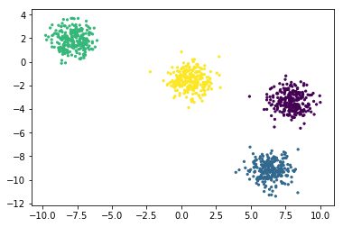

```python
plt.scatter(X[:,0],X[:,1],c=Y,s=5, cmap='viridis')
```

利用基尼系数的决策树实现：

```python
# DecisionTreeClassifier gini
clf = tree.DecisionTreeClassifier(criterion='gini')
```

进行训练

```python
def fit(trainX,trainY):
    dt = clf.fit(trainX,trainY)
    return dt

dt = fit(X,Y)
```

```python
plot_step = 0.2
x_min, x_max = X[:, 0].min() - 1, X[:, 0].max() + 1
y_min, y_max = X[:, 1].min() - 1, X[:, 1].max() + 1
xx, yy = np.meshgrid(np.arange(x_min, x_max, plot_step),
                         np.arange(y_min, y_max, plot_step))
```

### Calculation Outcome

你需要完成下面代码块中预测值的计算：

```python
def predict():
    return dt.predict(np.c_[xx.ravel(),yy.ravel()])
outcome = predict()
```

```python
xx.shape
```

```
(86, 109)
```

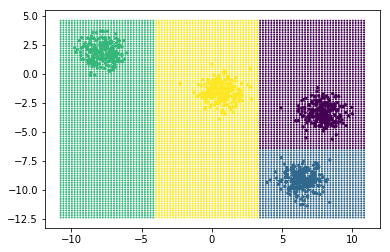

```python
plt.scatter(X[:,0],X[:,1],c=Y,s=5,cmap='viridis')
plt.scatter(xx.ravel(),yy.ravel(),c=outcome,s=1,alpha=1, cmap='viridis')
plt.show()
```

[figure not shown]